# Vessels

Jeffrey A. Walker

19 July, 2021

# Anatomy

1. Expand your knowledge of the type of vessels in a circuit: **large, elastic arteries -> small, muscular arteries -> arterioles -> capillaries -> venules -> veins**. Large elastic arteries have a relatively large fraction of **elastin** in the wall, which makes these walls **compliant** and **extensible** and good at storing **elastic strain energy**. High pressure blood flows in and pushes against the wall, the vessel expands and the walls absorb this strain-energy, and then as the high pressure blood flows past, the stretched wall uses this stored strain energy to maintain pressure. The muscular arteries have a relatively high fraction of smooth muscle in the wall. These arteries (especially the smaller ones) are used to regulate where blood flows to (which set of organs) and to regulate systemic blood pressure.
2. If you are in a little boat exiting the heart in the aorta you will travel through only a single capillary as you circulate back to the heart. That is, all of the capillaries are **in parallel**. There are a couple of important exceptions to this. 1) A **portal vein** is a vessel with the anatomy of a vein that exits the capillaries in one organ and travels to a 2nd set of capillaries in another organ. The two examples are the **hepatic portal vein** and the **hypothalamic-hypophyseal portal system**. These are both good to know because of the physiology. 2) In the kidney, an efferent arteriole leaves each glomerular capillary and travels to a second set of capillaries. We will learn about this in the renal/urinary unit.

# Hydrostatic Pressure

3. **Pressure** is force exerted on a wall or surface $Pressure = \frac{Force}{Area}$ where *Area* is the surface area of the wall. When I stand on the floor, I apply a pressure to the floor that is equal to my weight divided by the area of my shoes. If I wear clown shoes, I apply less pressure. If I wear high heels, I apply more pressure. Engineers worry about pressure. Elephants wearing high heels are a nightmare.
4. **fluid pressure** is the pressure that a fluid exerts on a wall or surface. A **fluid** is a material that flows if a force is applied to it. **Liquids** are fluids. **gases** and **gas mixtures** are fluids. The pressure that a fluid exerts on a wall is called the **hydrostatic pressure**. Let’s think about this. When I stand outside, the air (a gas mixture made of about 78% N2 and 21% O2 and 1% of lots of other stuff) pushes against my surface so there is air pressure. This pressure is about 1 ATM or 760 Torr or 760 mmHg. In A&P, we will typically use mmHg as the unit of pressure when talking about cardiovascular and respiratory systems. So this pressure is the force of the air pushing against my body divided by the surface area of my body. Where does this force come from? There are two ways of thinking about it: 1) The force comes from the **weight** of the column of air above me. Air extends from the earth’s surface to the edge of the atmosphere. The density of the gas molecules is highest right at the surface and is lowest at the edge of the atmosphere. Step over the edge and the density is effectively zero. Gravity pulls on the molecules toward the center of the earth, so the column of molecules above my head has a weight[^1] and this weight is the force. It is not only pushing down on my head but also pushing down on the air next to me, and that pressurized air next to me pushes against my body. 2) The **microscopic** way of thinking about the pressure in air (or any fluid under compression) is the air molecules are moving at thousands of miles per hour and are constantly colliding with my body. At collision some of the **kinetic energy** of the molecule is transfered to my body – this creates a small force on my body. At any instant in time there is some small fraction of molecules colliding against my body and the total force on my surface is the sum of each of the individual forces. This microscopic explanation is really useful moving foward.
5. **Flow** ($Flow = \frac{Pressure}{Resistance}$) is the rate that a volume of fluid moves past a point in space. In this equation, *Pressure* is the difference in pressure between two points (say the heart and some point downstream). Fluids from a region of high pressure to a region of low pressure. **Resistance to flow** comes from **friction**. Friction is the force that slows things down (or, removes kinetic energy from a moving object). In blood, this friction is not only due to the fluid sliding along the wall of the vessel but also from layers of the fluid sliding relative to other layers of the fluid. The stress (pressure) due to things sliding past things is **shear**. In a vessel with a large diameter lumen, only the edge of the blood has this shear but in a small vessels this shear extends across the whole diameter. Because of this, resistance to flow is much, much greater in small compared to large vessels.
6. The cardiovascular and respiratory systems are all about creating hydrostatic pressure differences to get fluids to flow. Blood moves from the ventricles out the arteries to the capillaries and then through the veins back to the heart because of a contiuous pressure drop along this path. The high pressure in the ventricles is created by the contraction of the ventricular walls, squeezing the blood in the chamber. In the respiratory system, we expand our lungs during inspiration, and this drops the air pressure in our lung **alveoli** to less than that of the air outside our body. This creates a pressure gradient that sucks outside air into our lungs. Then our expanded lungs and thorax contract (not muscularly!) and increase the alveolar pressure above that of the outside air, and so pushes the air back out. Anything transported in these fluids if moving by **bulk flow**.

# Osmotic pressure

Osmotic pressure is a strange concept because its not really a pressure. Instead, it is a difference in potential energy between two points due to concentration differences, and this energy difference is used to transport water across a membrane by diffusion, which is called osmosis. Because osmotic pressure drives diffusion (of water), it is only effective at very small scales and it is only a useful concept when thinking about water transport across biological membranes and not along a blood vessel.

At microscopic scales – such as that of **capillary exchange** – both osmosis and hydrostatic pressure are important for quantifying water transport across membranes so we need some way to combine the “driving force” due to osmosis and the “driving force” due to hydrostatic pressure. Osmotic pressure is the solution.

*Definition* – **osmotic pressure** is the driving force for the transport of water across a membrane by diffusion. Here is a slightly modified version of wikipedia’s definition: “Osmotic Pressure is the minimum pressure which needs to be applied to a solution to prevent the inward *net transport* of its pure solvent across a semipermeable membrane. It is also defined as the measure of the tendency of a solution to take in pure solvent by osmosis.”

Let’s illustrate this two ways.

Way number 1. What is the osmotic pressure of the blood plasma? Take a sample and put in a U-tube on what side of a membrane membrane that is impermeable to solutes but permeable to water. Then fill the other side with pure water to the level of the plasma. Because of the solute concentration gradient, there will be net transport of water across the membrane from the pure water side to the plasma side. The level of the plasma will rise and the level of the pure water will fall. As the level of the plasma side rises, the hydrostatic pressure on this side will rise because of increased weight of the column of plasma. As the level of the pure water side falls, the hydrostatic pressure on this side will fall because of the decreased weight of the column of water. So, as water moves from the water side to the plasma side, a difference in hydrostatic pressure develops and grows. Since the hydrostatic pressure is greater on the plasma side, there is a force due to this difference pushing water from the plasma side to the pure water side. Prior to equilibrium, the movement of water due to osmosis is greater than the movement of water due to the pressure difference and so the level on the plasma side continues to increase and that on the water side continues to fall. At equilibrium, the water movement due to the hydrostatic pressure difference equals that due to osmosis and there is no more net transport. This hydrostatic pressure difference is the osmotic pressure of the plasma.

In the image below, the red arrow is osmotic pressure and the blue arrow is the hydrostatic pressure.

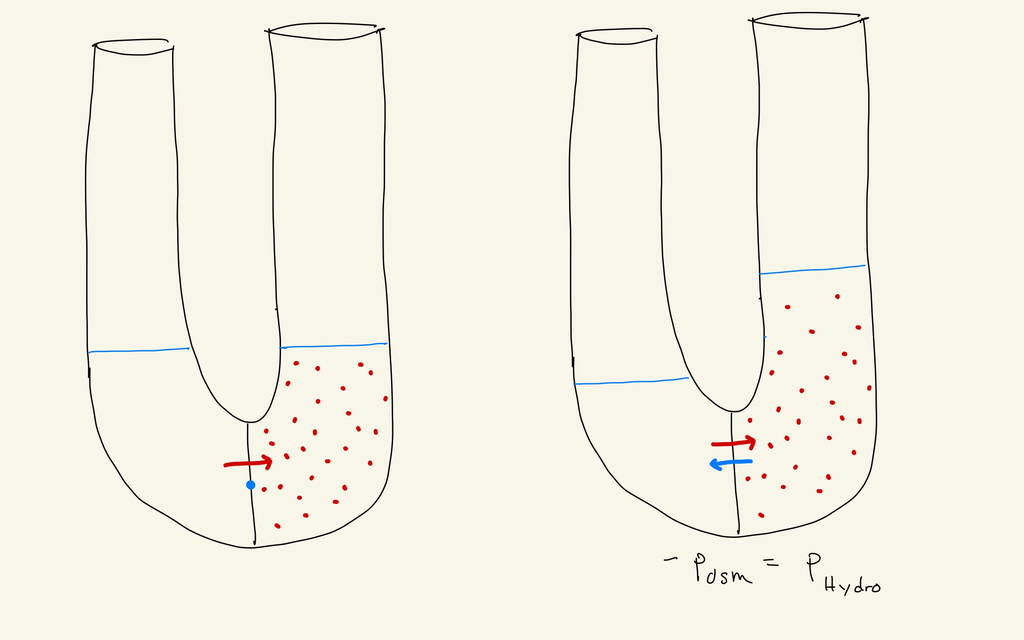

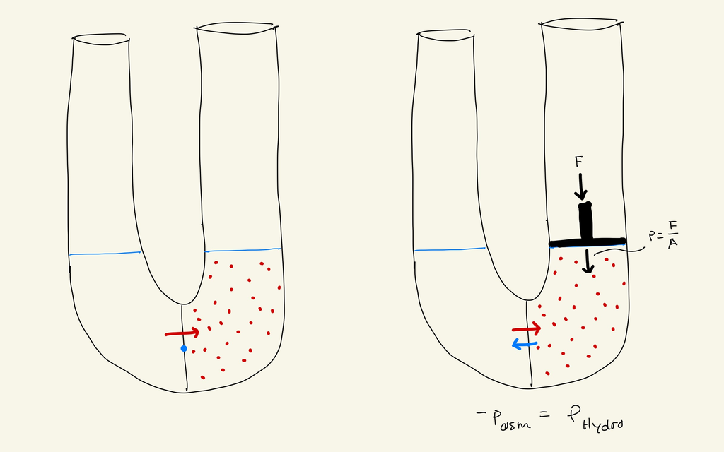

# The sign of osmotic pressure is negative

This is confusing. Trying to unconfuse it.

1. Water always move from more postive number to less positive number.
2. Osmotic pressures have a negative sign.
3. High osmotic pressure is a large, negative number
4. Low osmotic pressure is a small negative number.
5. Because #1, water moves by osmosis from more positive (small, negative number) to less positive (large, negative number), so from solution with low osmotic pressure to solution with high osmotic pressure.

Osmotic pressure in blood = -28 mmHg

Osmotic pressure in IF = -3 mmHg

-3 is more positive than -28 so water moves from IF (-3) to blood (-28)

# Capillary exchange

low hanging fruit concept 1: hydrostatic pressure is due to water pushing against a surface so if the surface is permeable to water then water is transported across the wall in one direction - down the pressure gradient. Think of a balloon with holes in it – all the water molecules move in the same direction – out of the balloon (no water goes in). The hydrostatic pressure in blood plasma is higher than that in the interstitial fluid so hydrostatic pressure is always “pushing” water across the epithelium into the interstium.

low hanging fruit concept 2. osmotic pressure is due to a solute concentration difference across the surface so if the surface is permeable to water than there is a **net transport** of water up the solute concentration gradient. The plasma always has a higher solute concentration than the interstitial fluid so there is always diffusion of water into the blood from the interstitial fluid. Sometimes I think of it as the osmotic pressure of the blood “sucks” water from the interstitium but this is not a great way to think about it because **suction** is a hydrostatic pressure concept.

## hydrostatic pressure and osmotic pressure in capillary exchange

There are two components to the net pressure: hydrostatic pressure (HP) and osmotic pressure (OP). Textbooks often treat both as positive but just state that OP is a “sucking instead of pushing” force. This can be quantitatively confusing so its better to make osmotic pressure negative, so that fluids always move from more positive to less positive. The key is: positive is in the direction from plasma to IF; negative is in the direction from IF to plasma.

# A & P textbook capillary exchange is usually presented kinda like this

**What’s happening downstream (venule end?)** There is a net HP of +15 mmHg and a net OP of -25 mmHg so we add these up and the net pressure is -10 mmHg. So there is net transport of water from the IF into the capillary.

Note these numbers are for teaching. In most capillaries the net pressure at the venule end is a little less in magnitude than that at the arteriole end and the consequence is there is net water loss as blood moves through a capillary. This lost water moves into the lymph – it is what creates lymph. It is what lymph is.

Important conceptually – don’t think of some water molecules as moving out of the blood because of HP and moving into the blood because of OP. The decomposition of the net pressure is entirely mathematical. It’s very similar to you swimming upstream in a river at 3 mph and the river is flowing downstream at 6 mph. Your net speed relative to land is 3 mph downstream.

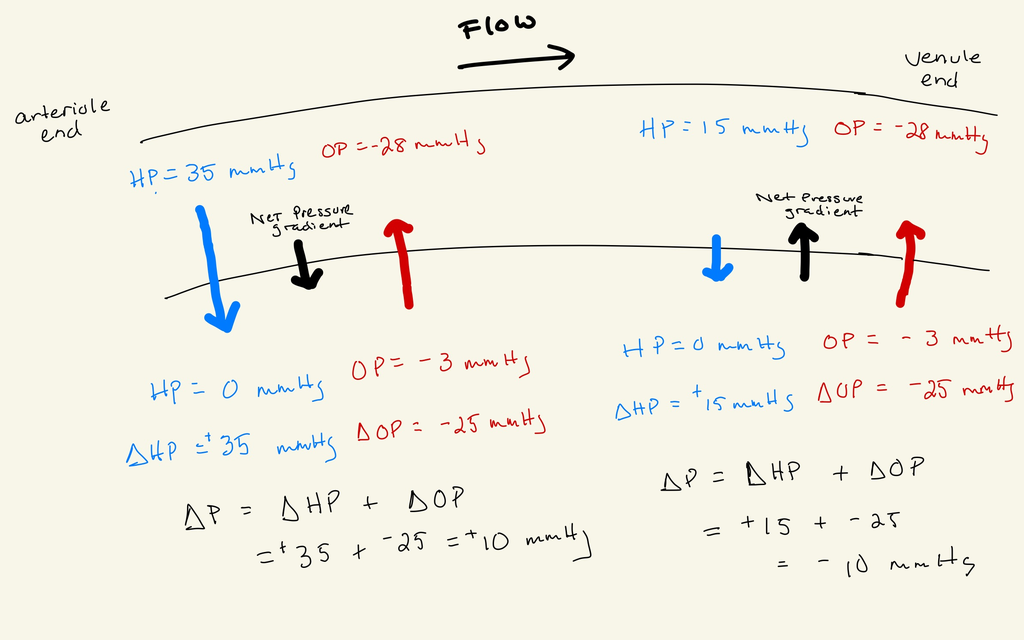

## A nice way to think about it because it really shows water moving down a pressure gradient

Notice that the black arrows point from a more positive number to a more negative number.

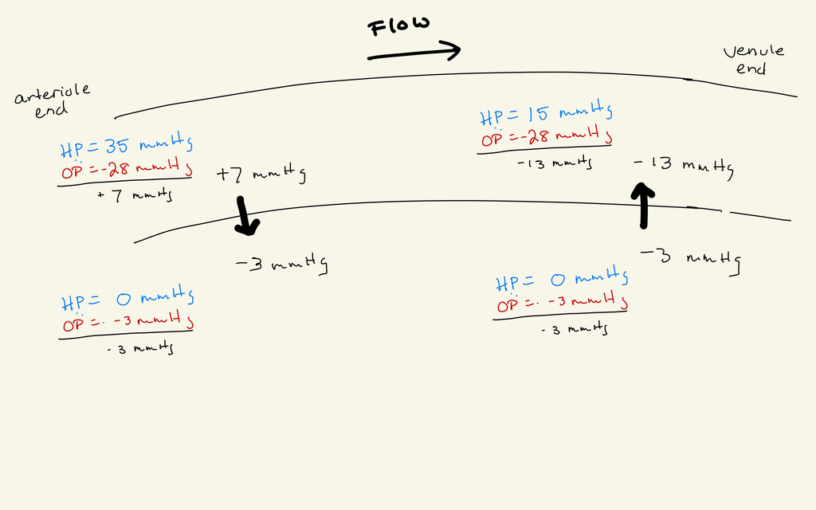

[^1]: approximately equal to $height \times area \times density$ where *height* is the distance from my head to the edge of the atmosphere, *area* is the cross-sectional area of the column of air (roughly my width x breadth), and *density* is the average density of the air molecules in the column.